# Tidy GHG Inventories

Tidy GHG Inventories

[William F. Lamb](https://lambwf.github.io/) | [Source Code](https://github.com/lambwf/Tidy-GHG-Inventories/)

The Tidy GHG Inventories dataset is a compilation of national greenhouse gas emissions (GHG) inventories, sourced from the Common Reporting Tables (CRTs) that countries submit to the UNFCCC. The CRTs themselves require significant manipulation before one can begin any data analysis. The objective of this dataset is therefore to put the national inventories into a single, tidy and consistently structured table format that better suits user needs.

[The data repository and documentation is available here.](https://doi.org/10.5281/zenodo.14512139)

Not all countries submit complete or timely inventories. Some inventories include only a few years of data, or data in individual years instead of the full time series since 1990. The map below shows how complete the dataset currently is.

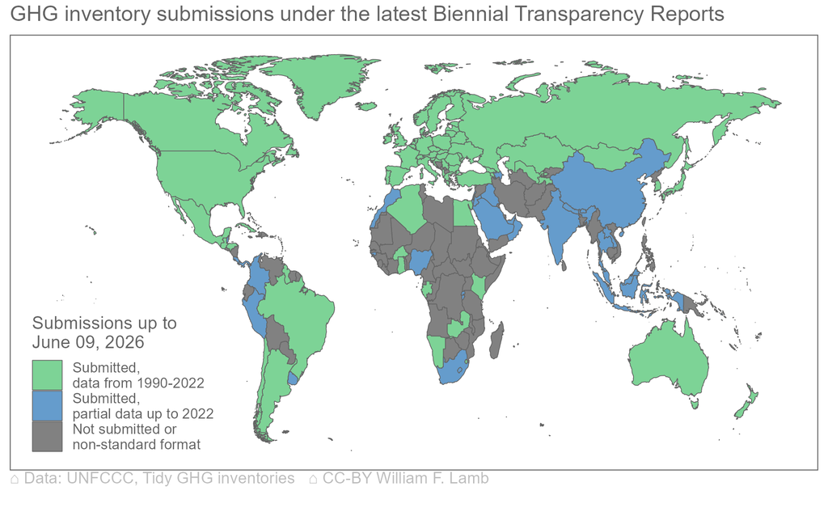

The following figures summarise the available data for nine inventory sectors. Many more sectors are available in the dataset, as well as memo items that are usually not counted in national totals. Please cite the figures or data as follows: Lamb, W. F. (2026). Tidy GHG Inventories (v2) [Data set]. Zenodo. https://doi.org/10.5281/zenodo.14512139

[figure not shown]

Albania | [data](https://raw.githubusercontent.com/lambwf/Tidy-GHG-Inventories/main/plots/countries/sectors/Albania-sectors.xlsx) | png | pdf | svg

[figure not shown]

Algeria | [data](https://raw.githubusercontent.com/lambwf/Tidy-GHG-Inventories/main/plots/countries/sectors/Algeria-sectors.xlsx) | png | pdf | svg

[figure not shown]

Argentina | [data](https://raw.githubusercontent.com/lambwf/Tidy-GHG-Inventories/main/plots/countries/sectors/Argentina-sectors.xlsx) | png | pdf | svg

[figure not shown]

Armenia | [data](https://raw.githubusercontent.com/lambwf/Tidy-GHG-Inventories/main/plots/countries/sectors/Armenia-sectors.xlsx) | png | pdf | svg

[figure not shown]

Australia | [data](https://raw.githubusercontent.com/lambwf/Tidy-GHG-Inventories/main/plots/countries/sectors/Australia-sectors.xlsx) | png | pdf | svg

[figure not shown]

Austria | [data](https://raw.githubusercontent.com/lambwf/Tidy-GHG-Inventories/main/plots/countries/sectors/Austria-sectors.xlsx) | png | pdf | svg

[figure not shown]

Azerbaijan | [data](https://raw.githubusercontent.com/lambwf/Tidy-GHG-Inventories/main/plots/countries/sectors/Azerbaijan-sectors.xlsx) | png | pdf | svg

[figure not shown]

Bahrain | [data](https://raw.githubusercontent.com/lambwf/Tidy-GHG-Inventories/main/plots/countries/sectors/Bahrain-sectors.xlsx) | png | pdf | svg

[figure not shown]

Belarus | [data](https://raw.githubusercontent.com/lambwf/Tidy-GHG-Inventories/main/plots/countries/sectors/Belarus-sectors.xlsx) | png | pdf | svg

[figure not shown]

Belgium | [data](https://raw.githubusercontent.com/lambwf/Tidy-GHG-Inventories/main/plots/countries/sectors/Belgium-sectors.xlsx) | png | pdf | svg

[figure not shown]

Belize | [data](https://raw.githubusercontent.com/lambwf/Tidy-GHG-Inventories/main/plots/countries/sectors/Belize-sectors.xlsx) | png | pdf | svg

[figure not shown]

Bhutan | [data](https://raw.githubusercontent.com/lambwf/Tidy-GHG-Inventories/main/plots/countries/sectors/Bhutan-sectors.xlsx) | png | pdf | svg

[figure not shown]

Brazil | [data](https://raw.githubusercontent.com/lambwf/Tidy-GHG-Inventories/main/plots/countries/sectors/Brazil-sectors.xlsx) | png | pdf | svg

[figure not shown]

Brunei | [data](https://raw.githubusercontent.com/lambwf/Tidy-GHG-Inventories/main/plots/countries/sectors/Brunei-sectors.xlsx) | png | pdf | svg

[figure not shown]

Bulgaria | [data](https://raw.githubusercontent.com/lambwf/Tidy-GHG-Inventories/main/plots/countries/sectors/Bulgaria-sectors.xlsx) | png | pdf | svg

[figure not shown]

Burkina Faso | data | png | pdf | svg

[figure not shown]

Burundi | [data](https://raw.githubusercontent.com/lambwf/Tidy-GHG-Inventories/main/plots/countries/sectors/Burundi-sectors.xlsx) | png | pdf | svg

[figure not shown]

Canada | [data](https://raw.githubusercontent.com/lambwf/Tidy-GHG-Inventories/main/plots/countries/sectors/Canada-sectors.xlsx) | png | pdf | svg

[figure not shown]

Chile | [data](https://raw.githubusercontent.com/lambwf/Tidy-GHG-Inventories/main/plots/countries/sectors/Chile-sectors.xlsx) | png | pdf | svg

[figure not shown]

China | [data](https://raw.githubusercontent.com/lambwf/Tidy-GHG-Inventories/main/plots/countries/sectors/China-sectors.xlsx) | png | pdf | svg

[figure not shown]

Colombia | [data](https://raw.githubusercontent.com/lambwf/Tidy-GHG-Inventories/main/plots/countries/sectors/Colombia-sectors.xlsx) | png | pdf | svg

[figure not shown]

Costa Rica | data | png | pdf | svg

[figure not shown]

Croatia | [data](https://raw.githubusercontent.com/lambwf/Tidy-GHG-Inventories/main/plots/countries/sectors/Croatia-sectors.xlsx) | png | pdf | svg

[figure not shown]

Cuba | [data](https://raw.githubusercontent.com/lambwf/Tidy-GHG-Inventories/main/plots/countries/sectors/Cuba-sectors.xlsx) | png | pdf | svg

[figure not shown]

Cyprus | [data](https://raw.githubusercontent.com/lambwf/Tidy-GHG-Inventories/main/plots/countries/sectors/Cyprus-sectors.xlsx) | png | pdf | svg

[figure not shown]

Czechia | [data](https://raw.githubusercontent.com/lambwf/Tidy-GHG-Inventories/main/plots/countries/sectors/Czechia-sectors.xlsx) | png | pdf | svg

[figure not shown]

Denmark | [data](https://raw.githubusercontent.com/lambwf/Tidy-GHG-Inventories/main/plots/countries/sectors/Denmark-sectors.xlsx) | png | pdf | svg

[figure not shown]

Egypt | [data](https://raw.githubusercontent.com/lambwf/Tidy-GHG-Inventories/main/plots/countries/sectors/Egypt-sectors.xlsx) | png | pdf | svg

[figure not shown]

Estonia | [data](https://raw.githubusercontent.com/lambwf/Tidy-GHG-Inventories/main/plots/countries/sectors/Estonia-sectors.xlsx) | png | pdf | svg

[figure not shown]

Eswatini | [data](https://raw.githubusercontent.com/lambwf/Tidy-GHG-Inventories/main/plots/countries/sectors/Eswatini-sectors.xlsx) | png | pdf | svg

[figure not shown]

European Union | data | png | pdf | svg

[figure not shown]

Finland | [data](https://raw.githubusercontent.com/lambwf/Tidy-GHG-Inventories/main/plots/countries/sectors/Finland-sectors.xlsx) | png | pdf | svg

[figure not shown]

France | [data](https://raw.githubusercontent.com/lambwf/Tidy-GHG-Inventories/main/plots/countries/sectors/France-sectors.xlsx) | png | pdf | svg

[figure not shown]

Gabon | [data](https://raw.githubusercontent.com/lambwf/Tidy-GHG-Inventories/main/plots/countries/sectors/Gabon-sectors.xlsx) | png | pdf | svg

[figure not shown]

Georgia | [data](https://raw.githubusercontent.com/lambwf/Tidy-GHG-Inventories/main/plots/countries/sectors/Georgia-sectors.xlsx) | png | pdf | svg

[figure not shown]

Germany | [data](https://raw.githubusercontent.com/lambwf/Tidy-GHG-Inventories/main/plots/countries/sectors/Germany-sectors.xlsx) | png | pdf | svg

[figure not shown]

Ghana | [data](https://raw.githubusercontent.com/lambwf/Tidy-GHG-Inventories/main/plots/countries/sectors/Ghana-sectors.xlsx) | png | pdf | svg

[figure not shown]

Greece | [data](https://raw.githubusercontent.com/lambwf/Tidy-GHG-Inventories/main/plots/countries/sectors/Greece-sectors.xlsx) | png | pdf | svg

[figure not shown]

Guatemala | [data](https://raw.githubusercontent.com/lambwf/Tidy-GHG-Inventories/main/plots/countries/sectors/Guatemala-sectors.xlsx) | png | pdf | svg

[figure not shown]

Guinea-Bissau | [data](https://raw.githubusercontent.com/lambwf/Tidy-GHG-Inventories/main/plots/countries/sectors/Guinea-Bissau-sectors.xlsx) | png | pdf | svg

[figure not shown]

Guyana | [data](https://raw.githubusercontent.com/lambwf/Tidy-GHG-Inventories/main/plots/countries/sectors/Guyana-sectors.xlsx) | png | pdf | svg

[figure not shown]

Honduras | [data](https://raw.githubusercontent.com/lambwf/Tidy-GHG-Inventories/main/plots/countries/sectors/Honduras-sectors.xlsx) | png | pdf | svg

[figure not shown]

Hungary | [data](https://raw.githubusercontent.com/lambwf/Tidy-GHG-Inventories/main/plots/countries/sectors/Hungary-sectors.xlsx) | png | pdf | svg

[figure not shown]

Iceland | [data](https://raw.githubusercontent.com/lambwf/Tidy-GHG-Inventories/main/plots/countries/sectors/Iceland-sectors.xlsx) | png | pdf | svg

[figure not shown]

India | [data](https://raw.githubusercontent.com/lambwf/Tidy-GHG-Inventories/main/plots/countries/sectors/India-sectors.xlsx) | png | pdf | svg

[figure not shown]

Indonesia | [data](https://raw.githubusercontent.com/lambwf/Tidy-GHG-Inventories/main/plots/countries/sectors/Indonesia-sectors.xlsx) | png | pdf | svg

[figure not shown]

Iraq | [data](https://raw.githubusercontent.com/lambwf/Tidy-GHG-Inventories/main/plots/countries/sectors/Iraq-sectors.xlsx) | png | pdf | svg

[figure not shown]

Ireland | [data](https://raw.githubusercontent.com/lambwf/Tidy-GHG-Inventories/main/plots/countries/sectors/Ireland-sectors.xlsx) | png | pdf | svg

[figure not shown]

Israel | [data](https://raw.githubusercontent.com/lambwf/Tidy-GHG-Inventories/main/plots/countries/sectors/Israel-sectors.xlsx) | png | pdf | svg

[figure not shown]

Italy | [data](https://raw.githubusercontent.com/lambwf/Tidy-GHG-Inventories/main/plots/countries/sectors/Italy-sectors.xlsx) | png | pdf | svg

[figure not shown]

Japan | [data](https://raw.githubusercontent.com/lambwf/Tidy-GHG-Inventories/main/plots/countries/sectors/Japan-sectors.xlsx) | png | pdf | svg

[figure not shown]

Jordan | [data](https://raw.githubusercontent.com/lambwf/Tidy-GHG-Inventories/main/plots/countries/sectors/Jordan-sectors.xlsx) | png | pdf | svg

[figure not shown]

Kazakhstan | [data](https://raw.githubusercontent.com/lambwf/Tidy-GHG-Inventories/main/plots/countries/sectors/Kazakhstan-sectors.xlsx) | png | pdf | svg

[figure not shown]

Kenya | [data](https://raw.githubusercontent.com/lambwf/Tidy-GHG-Inventories/main/plots/countries/sectors/Kenya-sectors.xlsx) | png | pdf | svg

[figure not shown]

Laos | [data](https://raw.githubusercontent.com/lambwf/Tidy-GHG-Inventories/main/plots/countries/sectors/Laos-sectors.xlsx) | png | pdf | svg

[figure not shown]

Latvia | [data](https://raw.githubusercontent.com/lambwf/Tidy-GHG-Inventories/main/plots/countries/sectors/Latvia-sectors.xlsx) | png | pdf | svg

[figure not shown]

Lebanon | [data](https://raw.githubusercontent.com/lambwf/Tidy-GHG-Inventories/main/plots/countries/sectors/Lebanon-sectors.xlsx) | png | pdf | svg

[figure not shown]

Liechtenstein | [data](https://raw.githubusercontent.com/lambwf/Tidy-GHG-Inventories/main/plots/countries/sectors/Liechtenstein-sectors.xlsx) | png | pdf | svg

[figure not shown]

Lithuania | [data](https://raw.githubusercontent.com/lambwf/Tidy-GHG-Inventories/main/plots/countries/sectors/Lithuania-sectors.xlsx) | png | pdf | svg

[figure not shown]

Luxembourg | [data](https://raw.githubusercontent.com/lambwf/Tidy-GHG-Inventories/main/plots/countries/sectors/Luxembourg-sectors.xlsx) | png | pdf | svg

[figure not shown]

Malaysia | [data](https://raw.githubusercontent.com/lambwf/Tidy-GHG-Inventories/main/plots/countries/sectors/Malaysia-sectors.xlsx) | png | pdf | svg

[figure not shown]

Maldives | [data](https://raw.githubusercontent.com/lambwf/Tidy-GHG-Inventories/main/plots/countries/sectors/Maldives-sectors.xlsx) | png | pdf | svg

[figure not shown]

Malta | [data](https://raw.githubusercontent.com/lambwf/Tidy-GHG-Inventories/main/plots/countries/sectors/Malta-sectors.xlsx) | png | pdf | svg

[figure not shown]

Mauritius | [data](https://raw.githubusercontent.com/lambwf/Tidy-GHG-Inventories/main/plots/countries/sectors/Mauritius-sectors.xlsx) | png | pdf | svg

[figure not shown]

Mexico | [data](https://raw.githubusercontent.com/lambwf/Tidy-GHG-Inventories/main/plots/countries/sectors/Mexico-sectors.xlsx) | png | pdf | svg

[figure not shown]

Moldova | [data](https://raw.githubusercontent.com/lambwf/Tidy-GHG-Inventories/main/plots/countries/sectors/Moldova-sectors.xlsx) | png | pdf | svg

[figure not shown]

Monaco | [data](https://raw.githubusercontent.com/lambwf/Tidy-GHG-Inventories/main/plots/countries/sectors/Monaco-sectors.xlsx) | png | pdf | svg

[figure not shown]

Mongolia | [data](https://raw.githubusercontent.com/lambwf/Tidy-GHG-Inventories/main/plots/countries/sectors/Mongolia-sectors.xlsx) | png | pdf | svg

[figure not shown]

Morocco | [data](https://raw.githubusercontent.com/lambwf/Tidy-GHG-Inventories/main/plots/countries/sectors/Morocco-sectors.xlsx) | png | pdf | svg

[figure not shown]

Namibia | [data](https://raw.githubusercontent.com/lambwf/Tidy-GHG-Inventories/main/plots/countries/sectors/Namibia-sectors.xlsx) | png | pdf | svg

[figure not shown]

Nepal | [data](https://raw.githubusercontent.com/lambwf/Tidy-GHG-Inventories/main/plots/countries/sectors/Nepal-sectors.xlsx) | png | pdf | svg

[figure not shown]

Netherlands | [data](https://raw.githubusercontent.com/lambwf/Tidy-GHG-Inventories/main/plots/countries/sectors/Netherlands-sectors.xlsx) | png | pdf | svg

[figure not shown]

New Zealand | data | png | pdf | svg

[figure not shown]

Nigeria | [data](https://raw.githubusercontent.com/lambwf/Tidy-GHG-Inventories/main/plots/countries/sectors/Nigeria-sectors.xlsx) | png | pdf | svg

[figure not shown]

Norway | [data](https://raw.githubusercontent.com/lambwf/Tidy-GHG-Inventories/main/plots/countries/sectors/Norway-sectors.xlsx) | png | pdf | svg

[figure not shown]

Oman | [data](https://raw.githubusercontent.com/lambwf/Tidy-GHG-Inventories/main/plots/countries/sectors/Oman-sectors.xlsx) | png | pdf | svg

[figure not shown]

Panama | [data](https://raw.githubusercontent.com/lambwf/Tidy-GHG-Inventories/main/plots/countries/sectors/Panama-sectors.xlsx) | png | pdf | svg

[figure not shown]

Peru | [data](https://raw.githubusercontent.com/lambwf/Tidy-GHG-Inventories/main/plots/countries/sectors/Peru-sectors.xlsx) | png | pdf | svg

[figure not shown]

Poland | [data](https://raw.githubusercontent.com/lambwf/Tidy-GHG-Inventories/main/plots/countries/sectors/Poland-sectors.xlsx) | png | pdf | svg

[figure not shown]

Portugal | [data](https://raw.githubusercontent.com/lambwf/Tidy-GHG-Inventories/main/plots/countries/sectors/Portugal-sectors.xlsx) | png | pdf | svg

[figure not shown]

Romania | [data](https://raw.githubusercontent.com/lambwf/Tidy-GHG-Inventories/main/plots/countries/sectors/Romania-sectors.xlsx) | png | pdf | svg

[figure not shown]

Russia | [data](https://raw.githubusercontent.com/lambwf/Tidy-GHG-Inventories/main/plots/countries/sectors/Russia-sectors.xlsx) | png | pdf | svg

[figure not shown]

Rwanda | [data](https://raw.githubusercontent.com/lambwf/Tidy-GHG-Inventories/main/plots/countries/sectors/Rwanda-sectors.xlsx) | png | pdf | svg

[figure not shown]

Saudi Arabia | data | png | pdf | svg

[figure not shown]

Serbia | [data](https://raw.githubusercontent.com/lambwf/Tidy-GHG-Inventories/main/plots/countries/sectors/Serbia-sectors.xlsx) | png | pdf | svg

[figure not shown]

Singapore | [data](https://raw.githubusercontent.com/lambwf/Tidy-GHG-Inventories/main/plots/countries/sectors/Singapore-sectors.xlsx) | png | pdf | svg

[figure not shown]

Slovakia | [data](https://raw.githubusercontent.com/lambwf/Tidy-GHG-Inventories/main/plots/countries/sectors/Slovakia-sectors.xlsx) | png | pdf | svg

[figure not shown]

Slovenia | [data](https://raw.githubusercontent.com/lambwf/Tidy-GHG-Inventories/main/plots/countries/sectors/Slovenia-sectors.xlsx) | png | pdf | svg

[figure not shown]

Solomon Islands | data | png | pdf | svg

[figure not shown]

South Africa | data | png | pdf | svg

[figure not shown]

South Korea | data | png | pdf | svg

[figure not shown]

Spain | [data](https://raw.githubusercontent.com/lambwf/Tidy-GHG-Inventories/main/plots/countries/sectors/Spain-sectors.xlsx) | png | pdf | svg

[figure not shown]

Sweden | [data](https://raw.githubusercontent.com/lambwf/Tidy-GHG-Inventories/main/plots/countries/sectors/Sweden-sectors.xlsx) | png | pdf | svg

[figure not shown]

Switzerland | [data](https://raw.githubusercontent.com/lambwf/Tidy-GHG-Inventories/main/plots/countries/sectors/Switzerland-sectors.xlsx) | png | pdf | svg

[figure not shown]

Tajikistan | [data](https://raw.githubusercontent.com/lambwf/Tidy-GHG-Inventories/main/plots/countries/sectors/Tajikistan-sectors.xlsx) | png | pdf | svg

[figure not shown]

Thailand | [data](https://raw.githubusercontent.com/lambwf/Tidy-GHG-Inventories/main/plots/countries/sectors/Thailand-sectors.xlsx) | png | pdf | svg

[figure not shown]

Turkey | [data](https://raw.githubusercontent.com/lambwf/Tidy-GHG-Inventories/main/plots/countries/sectors/Turkey-sectors.xlsx) | png | pdf | svg

[figure not shown]

Ukraine | [data](https://raw.githubusercontent.com/lambwf/Tidy-GHG-Inventories/main/plots/countries/sectors/Ukraine-sectors.xlsx) | png | pdf | svg

[figure not shown]

United Arab Emirates | data | png | pdf | svg

[figure not shown]

United Kingdom | data | png | pdf | svg

[figure not shown]

United States | data | png | pdf | svg

[figure not shown]

Uruguay | [data](https://raw.githubusercontent.com/lambwf/Tidy-GHG-Inventories/main/plots/countries/sectors/Uruguay-sectors.xlsx) | png | pdf | svg

[figure not shown]

Uzbekistan | [data](https://raw.githubusercontent.com/lambwf/Tidy-GHG-Inventories/main/plots/countries/sectors/Uzbekistan-sectors.xlsx) | png | pdf | svg

[figure not shown]

Vatican City | data | png | pdf | svg

[figure not shown]

Zambia | [data](https://raw.githubusercontent.com/lambwf/Tidy-GHG-Inventories/main/plots/countries/sectors/Zambia-sectors.xlsx) | png | pdf | svg